# Reproducible Research: Peer Assessment 1

Rajesh Ekkaladevi

Dec 10, 2018

## Loading and processing the data:

### Load reqd. libraries

```r
library(tidyverse)
library(lubridate)
library(knitr)
opts_knit$set(echo=TRUE, figure.path="figure/")
```

### Load activity data.

```r
activity <- read_csv("activity.zip")
glimpse(activity)
```

```
## Observations: 17,568
## Variables: 3
## $ steps    <int> NA, NA, NA, NA, NA, NA, NA, NA, NA, NA, NA, NA, NA, N...
## $ date     <date> 2012-10-01, 2012-10-01, 2012-10-01, 2012-10-01, 2012...
## $ interval <int> 0, 5, 10, 15, 20, 25, 30, 35, 40, 45, 50, 55, 100, 10...
```

### Add date_hms variable with date and time in datetime format.

```r
activity <- activity %>% mutate(date_hms = ymd_hm(sprintf("%s %04d", as.character(date), interval)))
```

```r
glimpse(activity)
```

```
## Observations: 17,568
## Variables: 4
## $ steps    <int> NA, NA, NA, NA, NA, NA, NA, NA, NA, NA, NA, NA, NA, N...
## $ date     <date> 2012-10-01, 2012-10-01, 2012-10-01, 2012-10-01, 2012...
## $ interval <int> 0, 5, 10, 15, 20, 25, 30, 35, 40, 45, 50, 55, 100, 10...
## $ date_hms <dttm> 2012-10-01 00:00:00, 2012-10-01 00:05:00, 2012-10-01...
```

## Histogram of the total number of steps taken each day:

### Steps_per_day, mean and median number of steps taken per day after filtering NAs.

```r
activity_day <- activity %>% select(date, steps) %>% filter(!is.na(steps)) %>% group_by(date) %>% summarize(steps_per_day = sum(steps))
```

```r
glimpse(activity_day)
```

```
## Observations: 53
## Variables: 2
## $ date          <date> 2012-10-02, 2012-10-03, 2012-10-04, 2012-10-05,...
## $ steps_per_day <int> 126, 11352, 12116, 13294, 15420, 11015, 12811, 9...
```

## Mean and median number of steps taken each day:

### Mean and median steps per day

```r
activity_day_mean_median <- activity_day %>% summarize(total_steps=sum(steps_per_day), mean_steps_per_day=mean(steps_per_day), median_steps_per_day=median(steps_per_day))
```

```r
activity_day_mean_median
```

```
## # A tibble: 1 x 3
##   total_steps mean_steps_per_day median_steps_per_day
##         <int>              <dbl>                <int>
## 1      570608             10766.                10765
```

### Plot showing histogram of steps_per_day across all days.

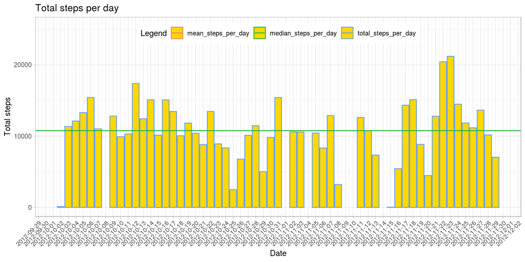

```r
ggplot(activity_day, aes(date, steps_per_day)) +
geom_bar(stat="identity", aes(color="total_steps_per_day"), fill="gold", size=.5, show.legend=TRUE) +
geom_hline(aes(yintercept=activity_day_mean_median$mean_steps_per_day, color="mean_steps_per_day"), size=.5, show.legend=TRUE) +
geom_hline( aes(yintercept=activity_day_mean_median$median_steps_per_day, color="median_steps_per_day"), size=0.5, show.legend=TRUE) +
labs(x="Date", y="Total steps", title="Total steps per day", color="Legend") +
scale_x_date(date_breaks="1 day", date_labels="%Y-%m-%d") +
theme_light() +
theme(axis.text.x=element_text(angle=45, vjust=1, hjust=1), legend.direction="horizontal", legend.position=c(0.5,0.92)) +
ylim(0,max(activity_day$steps_per_day)*1.2)
```

## Time series plot of the average number of steps taken by interval:

```r
activity_interval <- activity %>% filter(!is.na(steps)) %>% group_by(interval) %>% summarize(steps_per_interval = sum(steps), avg_steps_per_interval = round(mean(steps),2))
```

```r
glimpse(activity_interval)
```

```
## Observations: 288
## Variables: 3
## $ interval               <int> 0, 5, 10, 15, 20, 25, 30, 35, 40, 45, 5...
## $ steps_per_interval     <int> 91, 18, 7, 8, 4, 111, 28, 46, 0, 78, 16...
## $ avg_steps_per_interval <dbl> 1.72, 0.34, 0.13, 0.15, 0.08, 2.09, 0.5...
```

### Add interval_time variable from interval in datetime format for plotting.

```r
activity_interval_plot <- activity_interval %>% mutate(interval_time = as.POSIXct(strptime(sprintf("%04d", interval), "%H%M")))
```

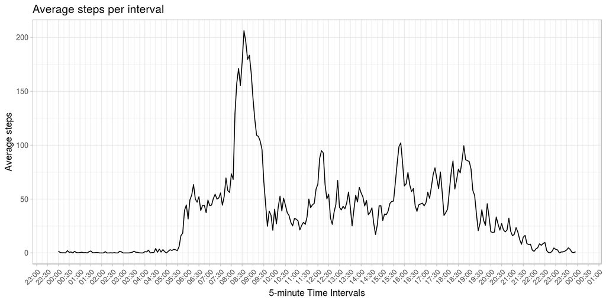

```r
ggplot(activity_interval_plot, aes(interval_time, avg_steps_per_interval)) +
geom_line() +
labs(x="5-minute Time Intervals", y="Average steps", title="Average steps per interval", color="Legend") +
scale_x_datetime(date_breaks="30 mins", date_labels="%H:%M") +
theme_light() +
theme(axis.text.x=element_text(angle=45, vjust=1, hjust=1), legend.direction="horizontal", legend.position=c(0.5,0.92))
```

### The 5-minute interval that, on average, contains the maximum number of steps.

```r
activity_interval %>% select(interval, avg_steps_per_interval) %>% filter(avg_steps_per_interval == max(avg_steps_per_interval))
```

```
## # A tibble: 1 x 2
##   interval avg_steps_per_interval
##      <int>                  <dbl>
## 1      835                   206.
```

From the above max average steps per interval is noticed on interval 835.

## Code to describe and show a strategy for imputing missing data:

### Find the number of NAs and its proportion in the data.

```r
activity %>% select(steps) %>% mutate(NAs = ifelse(is.na(steps), 'yes', 'no')) %>% group_by(NAs) %>% summarize(count = n()) %>% mutate(percent = count/sum(count))
```

```
## # A tibble: 2 x 3
##   NAs   count percent
##   <chr> <int>   <dbl>
## 1 no    15264   0.869
## 2 yes    2304   0.131
```

### Find the date’s on which NAs are there.

```r
activity %>% filter(is.na(steps)) %>% group_by(date) %>% summarize(n = n()) %>% mutate(cumulative_NAs = cumsum(n))
```

```
## # A tibble: 8 x 3
##   date           n cumulative_NAs
##   <date>     <int>          <int>
## 1 2012-10-01   288            288
## 2 2012-10-08   288            576
## 3 2012-11-01   288            864
## 4 2012-11-04   288           1152
## 5 2012-11-09   288           1440
## 6 2012-11-10   288           1728
## 7 2012-11-14   288           2016
## 8 2012-11-30   288           2304
```

The number of NAs from the above two snippets match to **2304** indicating on the days where the data is missing it is missing for the full day.

### Join original data set activity with activity_interval to get avg_steps_per_interval in the dataset.

```r
activity_joined <- left_join(activity, activity_interval)
head(activity_joined)
```

```
## # A tibble: 6 x 6
##   steps date       interval date_hms            steps_per_inter…
##   <int> <date>        <int> <dttm>                         <int>
## 1    NA 2012-10-01        0 2012-10-01 00:00:00               91
## 2    NA 2012-10-01        5 2012-10-01 00:05:00               18
## 3    NA 2012-10-01       10 2012-10-01 00:10:00                7
## 4    NA 2012-10-01       15 2012-10-01 00:15:00                8
## 5    NA 2012-10-01       20 2012-10-01 00:20:00                4
## 6    NA 2012-10-01       25 2012-10-01 00:25:00              111
## # ... with 1 more variable: avg_steps_per_interval <dbl>
```

### Impute all intervals where steps is NA.

```r
activity_imputed <- activity_joined %>% mutate(steps = ifelse(is.na(steps), avg_steps_per_interval, steps))
head(activity_imputed)
```

```
## # A tibble: 6 x 6
##   steps date       interval date_hms            steps_per_inter…
##   <dbl> <date>        <int> <dttm>                         <int>
## 1  1.72 2012-10-01        0 2012-10-01 00:00:00               91
## 2  0.34 2012-10-01        5 2012-10-01 00:05:00               18
## 3  0.13 2012-10-01       10 2012-10-01 00:10:00                7
## 4  0.15 2012-10-01       15 2012-10-01 00:15:00                8
## 5  0.08 2012-10-01       20 2012-10-01 00:20:00                4
## 6  2.09 2012-10-01       25 2012-10-01 00:25:00              111
## # ... with 1 more variable: avg_steps_per_interval <dbl>
```

### Check if all dates with step values as NA are updated.

```r
activity_imputed %>% filter(is.na(steps)) %>% group_by(date) %>% summarize(n = n()) %>% mutate(cumulative_NAs = cumsum(n))
```

```
## # A tibble: 0 x 3
## # ... with 3 variables: date <date>, n <int>, cumulative_NAs <int>
```

From the above all NAs are update hence no more NAs.

## Histogram of the total number of steps taken each day after missing values are imputed:

### Compute avg_steps_per_day on the imputed data.

```r
activity_imputed_day <- activity_imputed %>% select(date, steps) %>% group_by(date) %>% summarize(steps_per_day = sum(steps), avg_steps_per_day = mean(steps))
```

### Mean and median number of steps taken each day after data impute.

```r
activity_imputed_day_mean_median <- activity_imputed_day %>% summarize(total_steps=sum(steps_per_day), mean_steps_per_day=mean(steps_per_day), median_steps_per_day=median(steps_per_day))
```

```r
activity_imputed_day_mean_median
```

```
## # A tibble: 1 x 3
##   total_steps mean_steps_per_day median_steps_per_day
##         <dbl>              <dbl>                <dbl>
## 1     656737.             10766.               10766.
```

### Plot showing histogram of steps_per_day across all days after impute.

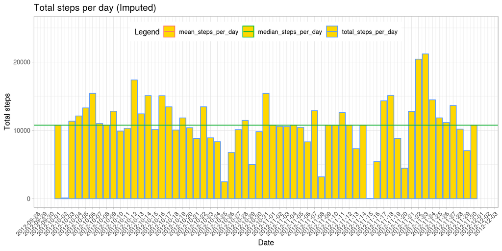

```r
ggplot(activity_imputed_day, aes(date, steps_per_day)) +
geom_bar(stat="identity", aes(color="total_steps_per_day"), fill="gold", size=.5, show.legend=TRUE) +
geom_hline(aes(yintercept=activity_imputed_day_mean_median$mean_steps_per_day, color="mean_steps_per_day"), size=.5, show.legend=TRUE) +
geom_hline( aes(yintercept=activity_imputed_day_mean_median$median_steps_per_day, color="median_steps_per_day"), size=0.5, show.legend=TRUE) +
labs(x="Date", y="Total steps", title="Total steps per day (Imputed)", color="Legend") +
scale_x_date(date_breaks="1 day", date_labels="%Y-%m-%d") +
theme_light() +
theme(axis.text.x=element_text(angle=45, vjust=1, hjust=1), legend.direction="horizontal", legend.position=c(0.5,0.92)) +
ylim(0,max(activity_day$steps_per_day)*1.2)
```

## Panel plot comparing the average number of steps taken per 5-minute interval across weekdays and weekends:

### Add weekday to the data using lubridate function.

```r
activity_imputed_week <- activity_imputed %>% mutate(weekday = as.character(wday(date, label=TRUE)), is_weekday = ifelse(wday(date, label=TRUE) %in% c("Mon", "Tue", "Wed", "Thu", "Fri"), "Weekday", "Weekend"))
str(activity_imputed_week)
```

```
## Classes 'tbl_df', 'tbl' and 'data.frame':    17568 obs. of  8 variables:
##  $ steps                 : num  1.72 0.34 0.13 0.15 0.08 2.09 0.53 0.87 0 1.47 ...
##  $ date                  : Date, format: "2012-10-01" "2012-10-01" ...
##  $ interval              : int  0 5 10 15 20 25 30 35 40 45 ...
##  $ date_hms              : POSIXct, format: "2012-10-01 00:00:00" "2012-10-01 00:05:00" ...
##  $ steps_per_interval    : int  91 18 7 8 4 111 28 46 0 78 ...
##  $ avg_steps_per_interval: num  1.72 0.34 0.13 0.15 0.08 2.09 0.53 0.87 0 1.47 ...
##  $ weekday               : chr  "Mon" "Mon" "Mon" "Mon" ...
##  $ is_weekday            : chr  "Weekday" "Weekday" "Weekday" "Weekday" ...
```

```r
activity_imputed_week_interval <- activity_imputed_week %>% group_by(interval, is_weekday) %>% mutate(avg_steps_per_interval = mean(steps))
head(activity_imputed_week_interval)
```

```
## # A tibble: 6 x 8
## # Groups:   interval, is_weekday [6]
##   steps date       interval date_hms            steps_per_inter…
##   <dbl> <date>        <int> <dttm>                         <int>
## 1  1.72 2012-10-01        0 2012-10-01 00:00:00               91
## 2  0.34 2012-10-01        5 2012-10-01 00:05:00               18
## 3  0.13 2012-10-01       10 2012-10-01 00:10:00                7
## 4  0.15 2012-10-01       15 2012-10-01 00:15:00                8
## 5  0.08 2012-10-01       20 2012-10-01 00:20:00                4
## 6  2.09 2012-10-01       25 2012-10-01 00:25:00              111
## # ... with 3 more variables: avg_steps_per_interval <dbl>, weekday <chr>,
## #   is_weekday <chr>
```

### Add interval_time variable from interval in datetime format for plotting.

```r
activity_imputed_week_interval_plot <- activity_imputed_week_interval %>% mutate(interval_time = as.POSIXct(strptime(sprintf("%04d", interval), "%H%M")))
```

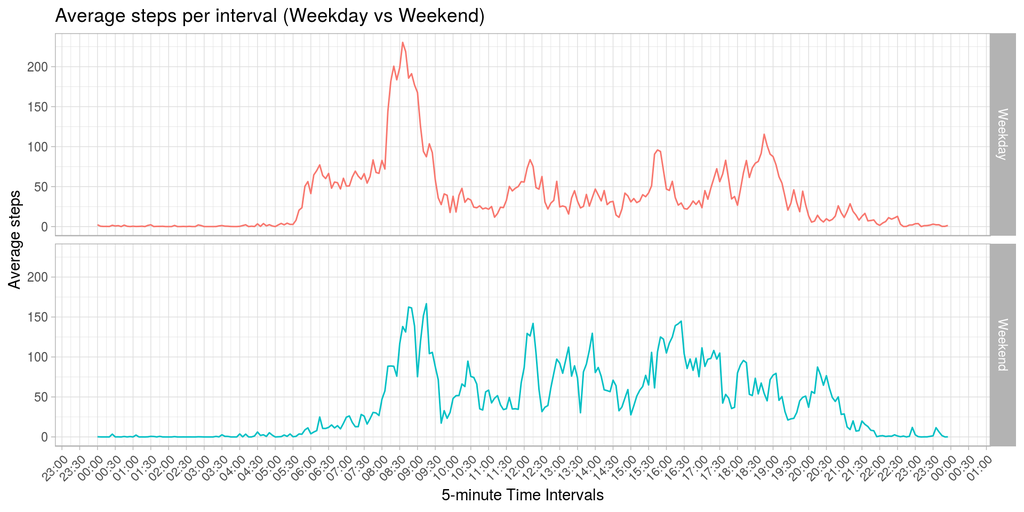

```r
ggplot(activity_imputed_week_interval_plot, aes(interval_time, avg_steps_per_interval, group=is_weekday, color=is_weekday)) +
geom_line() +
labs(x="5-minute Time Intervals", y="Average steps", title="Average steps per interval (Weekday vs Weekend)", color="Legend") +
scale_x_datetime(date_breaks="30 mins", date_labels="%H:%M") +
theme_light() +
theme(axis.text.x=element_text(angle=45, vjust=1, hjust=1), legend.position="none") +
facet_grid(is_weekday ~ .)
```

From the above the max number of steps are noticed on weekday.